```python
# setting up jupyter
%matplotlib inline
import matplotlib as mpl
mpl.rcParams['figure.dpi'] = 300
mpl.rcParams['savefig.dpi'] = 300
```

# Example 3 - defined *in vitro* differentiation of mESCs

This example features a merged dataset of 3 samples, each with its own control. In this context, we want to confirm the differentiation of motor neurons and cardiomyocytes, and further check transcriptional similarity for retinoic acid treated cells. This will include the use of *italic* labels, renaming sample elements, dealing with multiple samples instances and adjusting the minimum required detection threshold.

As always, we begin by initiating samples and targets. Since the input data for this experiment was gathered from different sources, the samples have separate controls. Therefore, we create three individual samples which take the expression data in the form of a *pandas.DataFrame* slice:

```python
from DPre import samples
import pandas as pd

# iniatite multiple sample data instances because of different controls
ivd_expr = pd.read_csv('ivd_expression.tsv', sep='\t', index_col='ensg')
# cardiomyocytes
cm_sample = samples(expression = ivd_expr.loc[:, ['ivd ESCs (cardio)', 'ivd cardiomyocytes']],    # syntax: loc[all rows, specifc columns]
                    ctrl = 'ivd ESCs (cardio)',
                    name = 'in vitro differentiated cardiomyocytes')
# motor neurons
mn_sample = samples(expression = ivd_expr.loc[:, ['ivd ESCs (mneu)', 'ivd motor neurons']],
                    ctrl = 'ivd ESCs (mneu)',
                    name = 'in vitro differentiated motor neurons')
# retinoic acid treated
ra_sample = samples(expression = ivd_expr.loc[:, ['ivd ESCs (ra)', 'ivd retinoic acid']],
                    ctrl = 'ivd ESCs (ra)',
                    name = 'in vitro differentiated ESCs +retinoic acid')
```

```
INFO-DPre _log_init:
=|=|=|=|=|=|=|=|====INITIATION====|=|=|=|=|=|=|=|=|=
New samples-instance created: `in vitro differentiated cardiomyocytes`
	samples (2):
		ivd ESCs (cardio),
		ivd cardiomyocytes
	Detected genes: 10251
	Differential genes loaded: False
	Expression data loaded: True
	Control passed: ivd ESCs (cardio)




INFO-DPre _log_init:
=|=|=|=|=|=|=|=|====INITIATION====|=|=|=|=|=|=|=|=|=
New samples-instance created: `in vitro differentiated motor neurons`
	samples (2):
		ivd ESCs (mneu),
		ivd motor neurons
	Detected genes: 10251
	Differential genes loaded: False
	Expression data loaded: True
	Control passed: ivd ESCs (mneu)




INFO-DPre _log_init:
=|=|=|=|=|=|=|=|====INITIATION====|=|=|=|=|=|=|=|=|=
New samples-instance created: `in vitro differentiated ESCs +retinoic acid`
	samples (2):
		ivd ESCs (ra),
		ivd retinoic acid
	Detected genes: 10251
	Differential genes loaded: False
	Expression data loaded: True
	Control passed: ivd ESCs (ra)
```

When initiating samples or targets, the number of detected genes is shown. In this data, the samples only list 10251 genes, which could result in low **proportions of detected target marker genes**. We can visualize those proportions with the *plot_detec_mgs_prop()* function:

```
INFO-DPre preset_targets:
Default targets `mouse` created, name: `mouse lineages`, elements: 272



INFO-DPre plot_color_legend:
Color legend generated and saved at C:\Users\LOaLoA\Anaconda3\Lib\DPre\examples\example3_ivd/mouse_color_legend.pdf

INFO-DPre plot_detec_mgs_prop:
Detection of targets (mouse lineages) marker genes in samples data (in vitro differentiated cardiomyocytes):
                                       n marker genes  detected in samples  proportion
up B cell (germinal center)                       354                   20    0.056497
   B cell (active)                                323                   20    0.061920
   Neutrophil +IL10 +LPS                          484                   32    0.066116
   Neutrophil -IL10 +LPS                          498                   34    0.068273
   Neutrophil +IL10 -LPS                          432                   30    0.069444
   Neutrophil -IL10 -LPS                          425                   30    0.070588
   CD4+ T NKG2D+ cells                            421                   30    0.071259
   B cell (naive)                                 303                   22    0.072607
   Spermatids (round)                            1295                   96    0.074131
   Spermatids (elongated)                        1280                   96    0.075000
   ESCs (ZHBTc4)                                  371                  309    0.832884
   Epiblast (E6.5) posterior-proximal             372                  310    0.833333
   EpiSC (region-selective)                       468                  391    0.835470
   Epiblast (E6.5) posterior-dorsal               374                  313    0.836898
   Epiblast (E6.5) anterior-proximal              375                  314    0.837333
   Epiblast (E6.5) anterior-dorsal                379                  319    0.841689
   EpiSC                                          500                  421    0.842000
   ESCs (E14)                                     500                  421    0.842000
   ESCs (V6.5)                                    536                  453    0.845149
   ESCs (B6J)                                     384                  340    0.885417
Shown are the 20 edge proportion values.
```

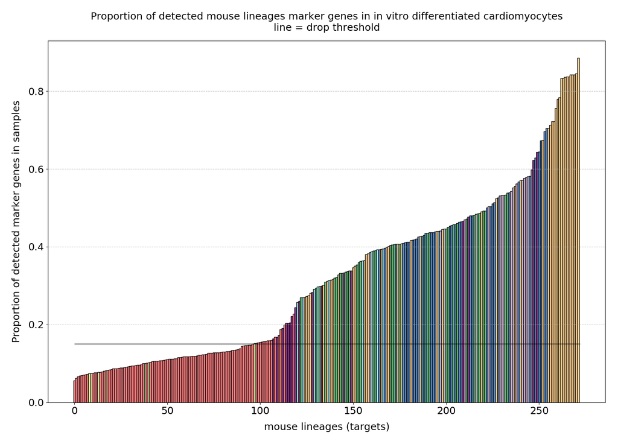

```
INFO-DPre plot_detec_mgs_prop:
Plot saved at C:\Users\LOaLoA\Anaconda3\Lib\DPre\examples\example3_ivd\trg_mgs_detec_prop.png
```

```python
from DPre import preset_targets

# initatie the target to compare against
t = preset_targets('mouse')
hist = t.plot_detec_mgs_prop(samples = cm_sample,
                             filename = 'trg_mgs_detec_prop.png',
                             plt_show = True,
                            )
```

Especially the blood mesoderm shows very low detection values. The default threshold of 15% delivered solid results in our testing, however, if too many targets are dropped or similarity scores seem off for low detection targets, feel free to adjust this value in *conifg.DROP_TARGET_DETEC_THR*. For temporal changes, pass DROP_TARGET_DETEC_THR to the similarity-plotting functions. Note however, that the change only applies if passed to the first plot in the script. For applying changes in the command line interface, the constant must be manually changed in the config file.